# Caso_Ponzo_GARCHvsSV

Sara Ponzo

2025-05-04

## TASK : Make a comparison between GARCH and stochastic volatility models.

To accomplish the task we have decided to analyse the behavior of ENI over the 2010-2024 period by:

1. Fitting 3 types of GARCH : standard, exponential and gjr.
2. Fitting 2 types of stochastic volatility model: leverage and t-distribution.
3. Verify the robustness of the model by analyzing the volatility clusters.
4. Make the comparison between all the models through the AIC and the RMSE to verify which model better forcast the future volatility.

## Why did we choose these types of models?

We have chosen to analyse the behavior of ENI because of the main patterns of the energy market, which is usually exposed to volatility clusters due to geopolitical risks and oil prices. Additionally, leverage effects and co-movements with commodities have a strong influence over the energy price too, making the negative news have a bigger influence on volatility.

Both garch and stochastic volatility models can be useful to recognize these features and when using these models we have to take into account both the strenghts and limitations they have.

We included the EGARCH and GJR-GARCH models because they allow us to capture asymmetric volatility responses, which are crucial in the energy market.

EGARCH models volatility in logarithmic form,removing the need to impose positivity constraints and allowing shocks of different signs to have different effects.

GJR-GARCH, on the other hand, introduces an indicator function that amplifies the effect of negative shock, which are very common in the energy market due to the leverage effect.

For the stochastic volatility models, the inclusion of a version with a Student’s t-distribution is essential to account for extreme market model more realistically, something the gaussian’s models are not able to do.

**When to use GARCH models?**

- To forecast short-term volatility;
- When we have high-frequency financial returns, like daily/hourly equity or FX data and conditional heteroskedasticity is pronounced;
- To have quick estimation and interpretable estimation, often using maximum likelihood.

**Limitations**

- They assume volatility is a deterministic function of past data;
- They are not ideal for capturing long memory or latent volatility shocks;
- Poorer fit for realistic volatility persistence and non-linearities.

**When to use stochastic volatility models?**

- To capture latent and persistent volatility. In fact, SV models treat volatility as a hidden stochastic process, better reflecting reality compared to Garch models;
- To model financial assets with strong regime shifts;
- To handle heavy tails and jumps. SV models with t-distribution or jump components model fat tails and sudden shock better.

**Limitations**

- Harder to compute, sometimes requiring MCMC or particle filters;
- Harder to implement in large-scale applications or real-time trading;
- Less intuitive.

## 1. GARCH estimation for ENI.

We upload the needed packages:

```r
library(quantmod)
library(tidyverse)
library(zoo)
library(quantmod)
library(rugarch)
library(stochvolTMB)
library(data.table)
```

```r
library(ggplot2)
library(reshape2)
library(changepoint)
library(patchwork)
library(ismev)
```

We upload the time series of ENI from 2010 to 2024 using the “quantmod” package. Specifically we use the getSymbols() function. We computed the daily log returns based on the closing prices of ENI, multiplied by 100 to express them in percentage terms.

```r
getSymbols("ENI.MI", from = "2010-01-01", to = "2024-12-31")
```

```
## [1] "ENI.MI"
```

```r
eni = `ENI.MI`
returns = na.omit(100 * diff(log(Cl(eni))))
```

In this part we use a 21-day rolling window (approximately one trading month) to compute the realized volatility. The object ‘align = “right”’ ensures that each value reflects the past 21 days ending at that point, which is ideal for forecasting and visualization. Additionally, we use the “fortify.zoo()” function to convert the zoo object into a data frame with a date column for plotting.

```r
realized_vol <- rollapply(returns, width = 21, FUN = sd, fill = NA, align = "right")
colnames(realized_vol) <- "RealizedVol"
vol_df <- fortify.zoo(realized_vol)
colnames(vol_df) <- c("Date", "RealizedVol")
```

Then, we ploy the realized rolling volatility to make a first visual check.

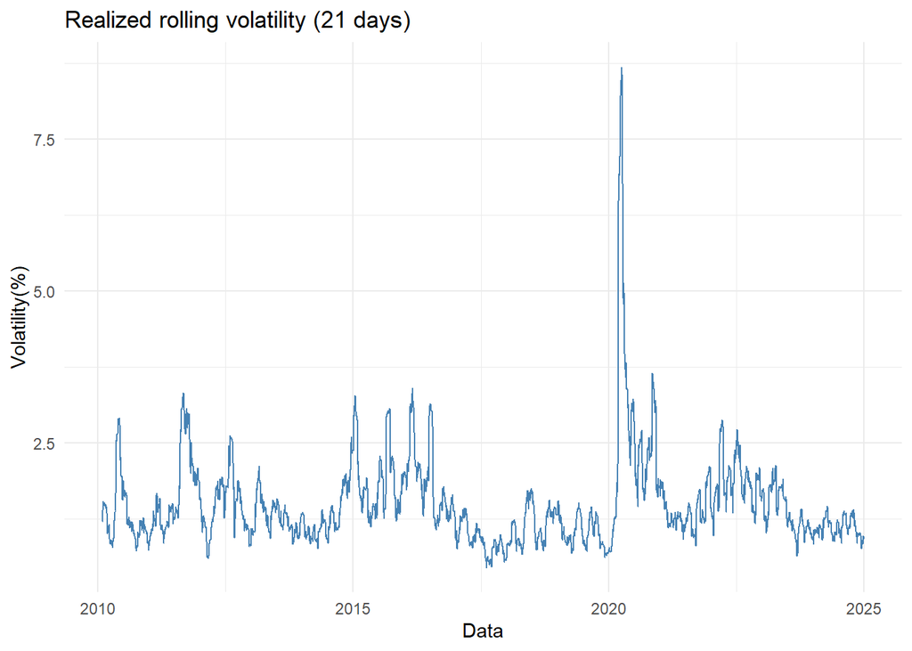

From the plot we can see that volatility is not constant, in fact it clusters in time which is ideal for using these types of models. Multiple clusters can be observed throught time:a high spike around march-april 2020 due to the Covid-19 pandemic, some other local smaller spikes around 2011-2012 due to the european sovereign debt crisis and around 2022 due to the russian invasion of Ukraine.

Volatility in GARCH models is **deterministically driven** by past squared returns and past volatility. In its standard form, the **GARCH(1,1)** model is written as:

$$\sigma_t^2 = \alpha_0 + \alpha_1 \epsilon_{t-1}^2 + \beta_1
\sigma_{t-1}^2$$

Where:

- $\sigma_t^2$ is the conditional variance at time $t$.
- $\epsilon_{t-1}$ is the return shock (innovation) at time $t-1$.
- $\alpha_0 > 0$, $\alpha_1 \geq 0$, and $\beta_1 \geq 0$ are parameters.

The model implies volatility depends on **past shocks and past volatility**.

### EGARCH and GJR-GARCH Extensions

Extensions like **EGARCH** (Exponential GARCH) and **GJR-GARCH** are designed to capture **asymmetry or leverage effects**.

#### GJR-GARCH(1,1) Specification:

$$\sigma_t^2 = \alpha_0 + \alpha_1 \epsilon_{t-1}^2 + \gamma_1
\epsilon_{t-1}^2 \cdot I_{\{\epsilon_{t-1} < 0\}} + \beta_1
\sigma_{t-1}^2$$

- $I_{\{\epsilon_{t-1} < 0\}}$ is an indicator function equal to 1 when the shock is negative.

#### EGARCH(1,1) Specification:

$$\log(\sigma_t^2) = \omega + \beta \log(\sigma_{t-1}^2) + \alpha
\frac{\epsilon_{t-1}}{\sigma_{t-1}} + \gamma \left( \left|
\frac{\epsilon_{t-1}}{\sigma_{t-1}} \right| - \mathbb{E}\left|
\frac{\epsilon_{t-1}}{\sigma_{t-1}} \right| \right)$$

- This formulation allows for **asymmetric effects** and guarantees non-negative variance **without needing parameter restrictions**.

### Distributional Assumptions

GARCH models typically assume that standardized residuals follow:

- A **normal distribution**,

or

- A **t-distribution** to better capture **fat tails** in financial returns.

Using the **t-distribution** we can model heavy tails than simply adjusting residuals in a normal GARCH.

**a. GARCH (1,1)**

We start from the ‘ugarchspec’ function included in the ‘rugarch’ package in which we specify the type of GARCH we want to compute, the standard GARCH.

Then we fit the model to the log returns and forecast 60 steps ahead and extract the forecasted sigma path.

```r
garch_spec = ugarchspec(
  variance.model = list(model = "sGARCH", garchOrder = c(1,1)),
  mean.model = list(armaOrder = c(0,0), include.mean = FALSE)
)
garch_fit = ugarchfit(spec = garch_spec, data = returns)
garch_forecast = ugarchforecast(garch_fit, n.ahead = 60)
garch_vol = sigma(garch_forecast)
```

**b. e-GARCH**

Here we specify that we want to compute an eGARCH(1,1) which models the log of variance, ensuring positivity without parameter constraints and captures asymmetric effects.

```r
egarch_spec = ugarchspec(
  variance.model = list(model = "eGARCH", garchOrder = c(1,1)),
  mean.model = list(armaOrder = c(0,0), include.mean = FALSE)
)
egarch_fit = ugarchfit(spec = egarch_spec, data = returns)
egarch_forecast = ugarchforecast(egarch_fit, n.ahead = 60)
egarch_vol = sigma(egarch_forecast)
```

**c. gjr -GARCH**

Finally, we compute the gjr-GARCH that accounts better for negative shocks.

```r
gjr_spec = ugarchspec(
  variance.model = list(model = "gjrGARCH", garchOrder = c(1,1)),
  mean.model = list(armaOrder = c(0,0), include.mean = FALSE)
)
gjr_fit = ugarchfit(spec = gjr_spec, data = returns)
gjr_forecast = ugarchforecast(gjr_fit, n.ahead = 60)
gjr_vol = sigma(gjr_forecast)
```

## 2. Stochastic volatility Models estimation for ENI.

Differently from GARCH, stochastic volatility (SV) models treat volatility as an unobserved (latent) stochastic process that evolves over time:

$$\log(\sigma_t^2) = \mu + \phi \log(\sigma_{t-1}^2) + \eta_t$$

Volatility follows a process with random innovations terms $\eta_t$, making it more flexible and realistic in capturing features like long memory, sudden shifts, and persistent clustering.

This structural difference explains why SV models often outperform GARCH models in modeling real market volatility, especially over longer horizons or during unstable economic cycles.

We will estimate and forecast volatility using two SV models: one with leverage effects and one with Student t distribution.

**a. Leverage**

We use the estimate_parameters() function specifyng the type of SV model we want to compute and then predict() to forecast the volatility.

```r
sv_lev = estimate_parameters(as.numeric(returns), model = "leverage", silent = TRUE)
sv_lev_pred = predict(sv_lev, steps = 60, include_parameters = TRUE)
sv_lev_vol = summary(sv_lev_pred)$h_exp$mean
```

**b. t-distribution**

We do the same for the t-distribution SV model.

```r
sv_t = estimate_parameters(as.numeric(returns), model = "t", silent = TRUE)
sv_t_pred = predict(sv_t, steps = 60, include_parameters = TRUE)
sv_t_vol = summary(sv_t_pred)$h_exp$mean
```

## 3. Verify the robustness of the model by analyzing the volatility clusters.

**Predictions**

We start by analysing the predictions of the different models.

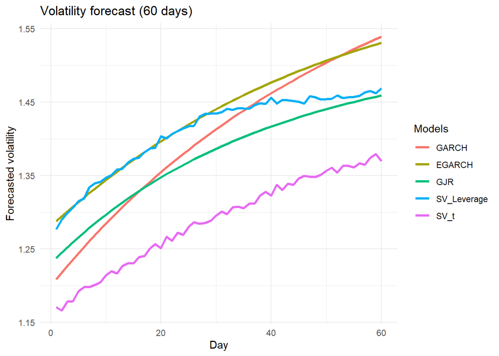

```r
result_df = data.frame(
  Day = 1:60,
  GARCH = as.numeric(garch_vol),
  EGARCH = as.numeric(egarch_vol),
  GJR = as.numeric(gjr_vol),
  SV_Leverage = sv_lev_vol,
  SV_t = sv_t_vol
)

melted = melt(result_df, id.vars = "Day")

ggplot(melted, aes(x = Day, y = value, color = variable)) +
  geom_line(size = 1.2) +
  labs(title = "Volatility forecast (60 days)",
       x = "Day", y = "Forecasted volatility",
       color = "Models") +
  theme_minimal()
```

The predictions highlight an increase in volatility over the next 60 days for all the considered models.

However, to avoids interpreting volatility forecasts without a context,it is important to identify the eventualvolatility clusters, which provide a meaningful temporal framework for evaluating the models and their ability to forecasts alongside RMSE and AIC.

We can perform a ‘changepoint’ analysis using the PELT method which identifies several statistically significant change points in the variance of the returns in the data. These change points mark the transitions between periods of different volatility levels.

The segments extracted from the changepoint analysis can be used to validate model predictions: if a model predicts elevated volatility during a cluster labeled as “high volatility” (or viceversa) its output aligns with the empirical classification and highlight a robust model. This qualitative consistency reinforces the quantitative metrics like AIC and RMSE.

```r
y <- as.numeric(returns)
cpt <- cpt.var(y, method = "PELT", penalty = "MBIC")
summary(cpt)
```

```
## Created Using changepoint version 2.3
## Changepoint type      : Change in variance
## Method of analysis    : PELT
## Test Statistic  : Normal
## Type of penalty       : MBIC with value, 24.73694
## Minimum Segment Length : 2
## Maximum no. of cpts   : Inf
## Changepoint Locations : 403 469 955 1199 1766 2574 2604 2795 3024 3411
```

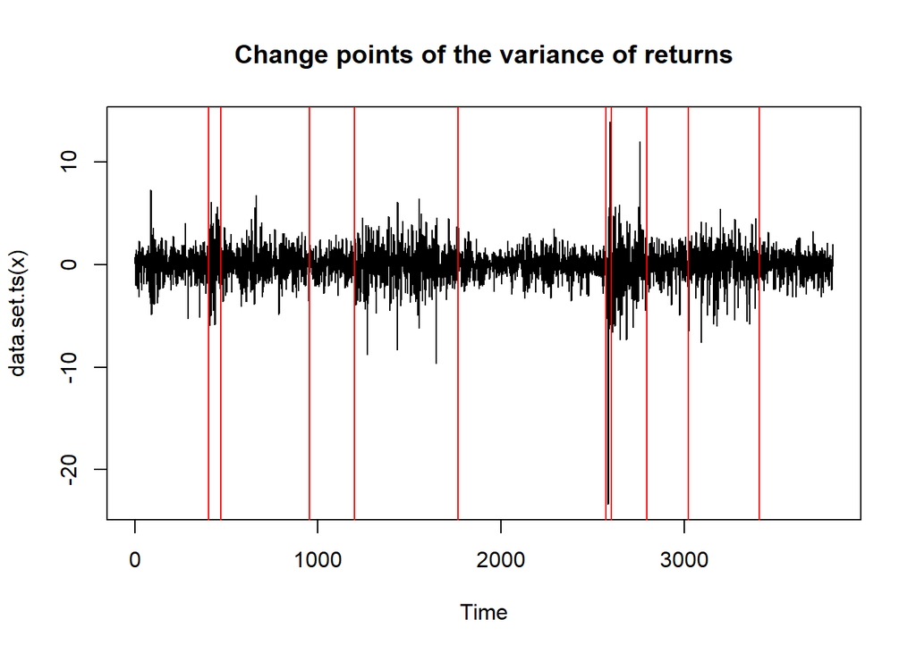

```r
plot(cpt, main = "Change points of the variance of returns")
```

```r
changepoints <- cpts(cpt)
print(changepoints)
```

```
##  [1]  403  469  955 1199 1766 2574 2604 2795 3024 3411
```

The fact that we find multiple statistically significant change points within the observed period further supports the presence of volatility clustering.

The ability of a model to adapt to such shifts is crucial for forecasting. Models like GJR-GARCH and EGARCH, which explicitly capture asymmetric responses to shocks, are expected to better reflect such transitions.

However, SV models are able to have even better results in this scenario, especially the one with a Student t distribution errors, which not only allow for regime-dependent behavior but also model the uncertainty about volatility itself.

In the following part we will try to extract the standard deviation for different ranges of periods and the corresponding type of volatility (high or low).

We start by defining a vector called ‘breaks’ to encapsulate all the different change point. This is important to divide the time series in segments based on the change points. We created a for loop to iterate through the breaks vector to extract the subset of the returns corresponding to each segment.

If the extracted standard deviation is bigger than the standard deviation of the returns the assigned status is “high volatility”, viceversa for standard deviations smaller than the general one.

```r
cp_index <- cpts(cpt)
breaks <- c(1, cp_index, length(y))
global_sd <- sd(y)
cluster_list <- list()

for (i in 1:(length(breaks) - 1)) {
  start <- breaks[i]
  end <- breaks[i + 1]
  segment <- y[start:end]
  segment_sd <- sd(segment)
  status <- ifelse(segment_sd > global_sd, "High volatility", "Low volatility")
  cluster_list[[i]] <- data.frame(
    Start = index(returns)[start],
    End = index(returns)[end],
    SD = round(segment_sd, 4),
    Cluster = status
  )
}

cluster_df <- do.call(rbind, cluster_list)
print(cluster_df)
```

```
##         Start        End     SD         Cluster
## 1  2010-01-05 2011-07-29 1.3685  Low volatility
## 2  2011-07-29 2011-11-01 2.8610 High volatility
## 3  2011-11-01 2013-10-01 1.5055  Low volatility
## 4  2013-10-01 2014-09-19 1.0871  Low volatility
## 5  2014-09-19 2016-12-12 1.9761 High volatility
## 6  2016-12-12 2020-02-21 1.0737  Low volatility
## 7  2020-02-21 2020-04-03 7.1895 High volatility
## 8  2020-04-03 2021-01-06 2.5571 High volatility
## 9  2021-01-06 2021-11-25 1.2836  Low volatility
## 10 2021-11-25 2023-06-02 1.8788 High volatility
## 11 2023-06-02 2024-12-30 1.1167  Low volatility
```

Comparing the average predicted volatility of each model to the standard deviation threshold used in the changepoint clustering, we find that all forecasts remain within the range of low-volatility cluster.

```r
forecast_means <- colMeans(result_df[, -1])
forecast_classification <- ifelse(forecast_means > global_sd,
                                  "High volatility forcasted",
                                  "Low volatility forcasted")

forecast_df <- data.frame(
  Models = names(forecast_means),
  Forcasted_mean = round(forecast_means, 4),
  Cluster = forecast_classification
)

print(forecast_df)
```

```
##                  Models Forcasted_mean                  Cluster
## GARCH             GARCH         1.4016 Low volatility forcasted
## EGARCH           EGARCH         1.4311 Low volatility forcasted
## GJR                 GJR         1.3749 Low volatility forcasted
## SV_Leverage SV_Leverage         1.4113 Low volatility forcasted
## SV_t               SV_t         1.2878 Low volatility forcasted
```

The agreement between historical clustering and forecasted volatility levels supports the robustness of the modeling framework.

## 4. Comparison between the models through the AIC and the RMSE.

**AIC: akaike information criterion**

The AIC is used to compare different statistical models and assess their goodness of fit while penalizing model complexity (number of parameters). A lower AIC generally indicates a better model in terms of balancing fit and parsimony.

To make a consistent comparison we have decided to calculate the AIC of the GARCH models using the formula and not the direct function AIC(). In this way we have an explicit control over the number of parameters to use.

```r
k_garch <- 3
k_egarch <- 3
k_gjr <- 3
ll_garch  <- garch_fit@fit$LLH
ll_egarch <- egarch_fit@fit$LLH
ll_gjr    <- gjr_fit@fit$LLH

aic_garch  <- -2 * ll_garch + 2 * k_garch
aic_egarch <- -2 * ll_egarch + 2 * k_egarch
aic_gjr    <- -2 * ll_gjr + 2 * k_gjr

aic_lev<-AIC(sv_lev)
aic_t<-AIC(sv_t)

aic_df <- data.frame(
  Models = c("GARCH(1,1)", "EGARCH(1,1)", "GJR-GARCH(1,1)", "SV Leverage", "SV t-distribuzione"),
  AIC = c(aic_garch, aic_egarch, aic_gjr, aic_lev, aic_t)
)

print(aic_df[order(aic_df$AIC), ])
```

```
##               Models      AIC
## 4        SV Leverage 13609.32
## 5 SV t-distribuzione 13626.71
## 3     GJR-GARCH(1,1) 13769.42
## 2        EGARCH(1,1) 13776.54
## 1         GARCH(1,1) 13841.29
```

- The SV Leverage model has the lowest AIC, suggesting it provides the best fit according to this criterion.
- The SV t-distribution model has the second-lowest AIC.
- The GARCH family models have higher AIC values, indicating a relatively poorer fit compared to the stochastic volatility models based on AIC.

**RMSE: root mean squared error**

The RMSE measures the average magnitude of the errors between 1 the predicted values and the actual (realized) values. A lower RMSE indicates that the predictions are closer to the actual values.

We use the rmse() function to compute it.

```r
getSymbols("ENI.MI", from = "2025-01-01", to = "2025-03-31")
```

```
## [1] "ENI.MI"
```

```r
eni_2025 <- `ENI.MI`
returns_2025 <- na.omit(100 * diff(log(Cl(eni_2025))))

returns_test <- as.numeric(returns_2025[1:60])

realized_vol_2025 <- sqrt(rollmean(returns_test^2, k = 2, align = "right", na.pad = FALSE))
realized_vol_2025 <- realized_vol_2025[1:59]

pred_garch <- result_df$GARCH[2:60]
pred_egarch <- result_df$EGARCH[2:60]
pred_gjr <- result_df$GJR[2:60]
pred_sv_lev <- result_df$SV_Leverage[2:60]
pred_sv_t <- result_df$SV_t[2:60]

rmse <- function(true, predicted) {
  sqrt(mean((true - predicted)^2, na.rm = TRUE))
}

rmse_values <- data.frame(
  Models = c("GARCH", "EGARCH", "GJR-GARCH", "SV Leverage", "SV t-dist"),
  RMSE = c(
    rmse(realized_vol_2025, pred_garch),
    rmse(realized_vol_2025, pred_egarch),
    rmse(realized_vol_2025, pred_gjr),
    rmse(realized_vol_2025, pred_sv_lev),
    rmse(realized_vol_2025, pred_sv_t)
  )
)

print(rmse_values[order(rmse_values$RMSE), ])
```

```
##        Models      RMSE
## 5   SV t-dist 0.7120097
## 3   GJR-GARCH 0.7640247
## 1       GARCH 0.7769960
## 4 SV Leverage 0.7911712
## 2      EGARCH 0.7990067
```

- The SV t-dist model has the lowest RMSE as it is expected, suggesting it provided then most accurate volatility forecasts compared to the realized volatility (calculated using a 2-day rolling window).
- The GJR-GARCH and GARCH models also show relatively low RMSE values.
- The SV Leverage and EGARCH models have higher RMSE values,indicating relatively less accurate predictions compared to the other models based on this metric.

# A visual comparison of the models results and the realized volatility

We analyze the latent volatility dynamics obtained from the stochastic volatility models, comparing it with the rolling realized volatility for the 21-day interval we previously estimated.

In fact, after estimating the models is it possible to calculate, through the parameters produced by the summary, the conditional standard deviation of returns, which permit us to make a direct comparison with the Garchs results.

1. **SV leverage model**

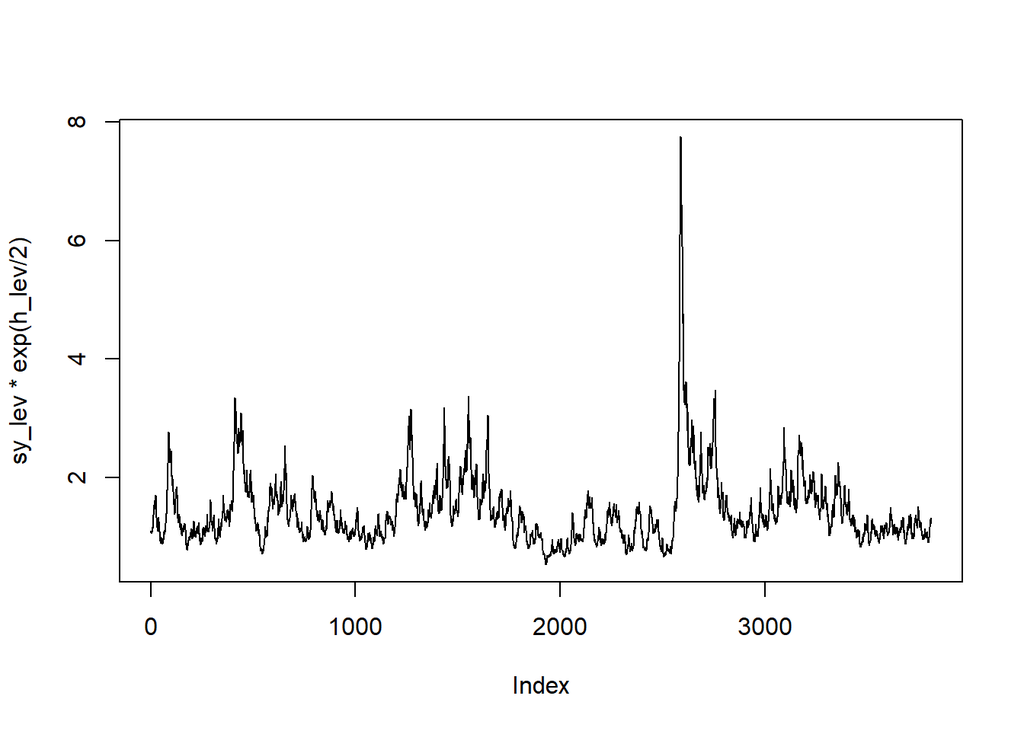

```r
h_lev=summary(sv_lev)$estimate[-c(1:6)]
h_lev<-as.vector(h_lev)
h_lev<-h_lev[-c(1:2)]
sy_lev=summary(sv_lev)$estimate[1]
plot(sy_lev*exp(h_lev/2), type="l")
```

2. **SV t-distribution model**

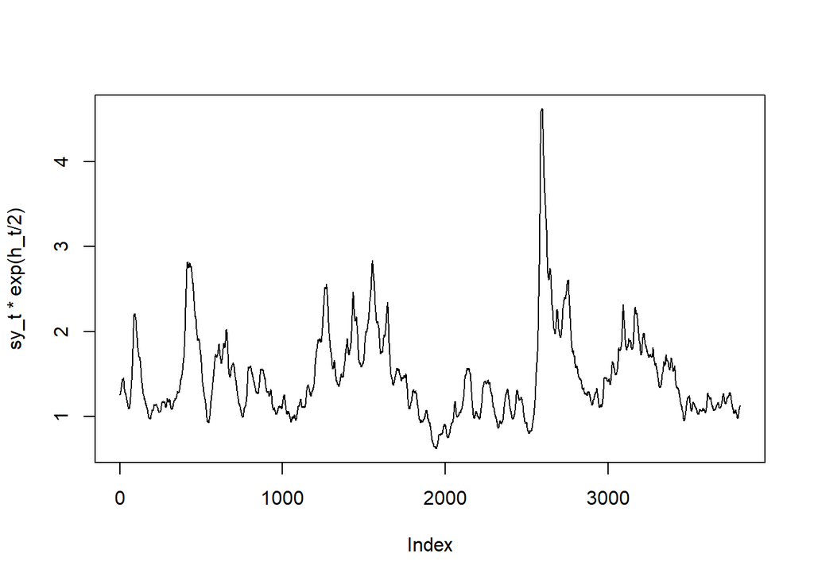

```r
h_t=summary(sv_t)$estimate[-c(1:6)]
h_t<-as.vector(h_t)
h_t<-h_t[-c(1:2)]
sy_t=summary(sv_t)$estimate[1]
plot(sy_t*exp(h_t/2), type="l")
```

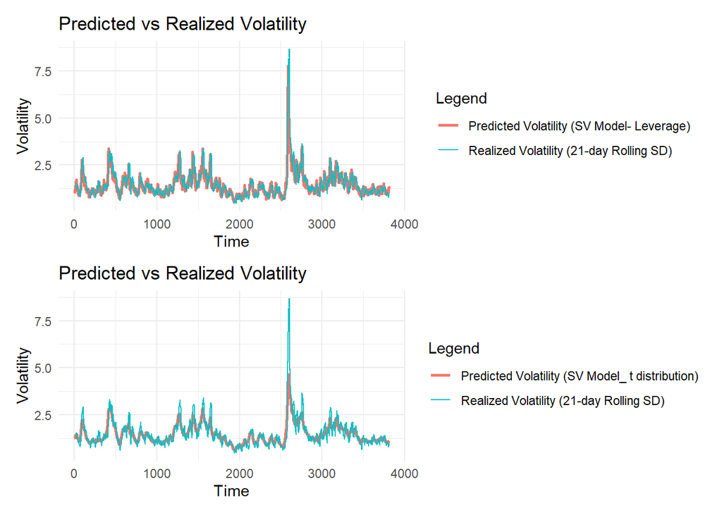

```r
min_len_lev <- min(length(as.numeric(sy_lev*exp(h_lev/2))), length(realized_vol), length(returns))
df <- data.frame(
  Time = 1:min_len_lev,
  PredictedVol = (sy_lev*exp(h_lev/2))[1:min_len_lev],
  RealizedVol = realized_vol[1:min_len_lev]
)
p1 <- ggplot(df, aes(x = Time)) +
  geom_line(aes(y = PredictedVol, color = "Predicted Volatility (SV Model- Leverage)"), size = 1) +
  geom_line(aes(y = RealizedVol, color = "Realized Volatility (21-day Rolling SD)"), size = 0.5) +
  labs(
    title = "Predicted vs Realized Volatility",
    x = "Time",
    y = "Volatility",
    color = "Legend"
  ) +
  theme_minimal()

min_len_t <- min(length(as.numeric(sy_t*exp(h_t/2))), length(realized_vol), length(returns))
df <- data.frame(
  Time = 1:min_len_t,
  PredictedVol = (sy_t*exp(h_t/2))[1:min_len_t],
  RealizedVol = realized_vol[1:min_len_t]
)

p2 <- ggplot(df, aes(x = Time)) +
  geom_line(aes(y = PredictedVol, color = "Predicted Volatility (SV Model_ t distribution)"), size = 1) +
  geom_line(aes(y = RealizedVol, color = "Realized Volatility (21-day Rolling SD)"), size = 0.5) +
  labs(
    title = "Predicted vs Realized Volatility",
    x = "Time",
    y = "Volatility",
    color = "Legend"
  ) +
  theme_minimal()
p1/p2
```

3. **GARCH models**

The same procedure is applied to the Garch models, so that we are able to extract the conditional volatility and plot it against the 21-day rolling volatility of the returns. The visual comparison helps us evaluate how well the models adapt to periods of high and low market turbulence, and understand if the models are able to catch shocks.

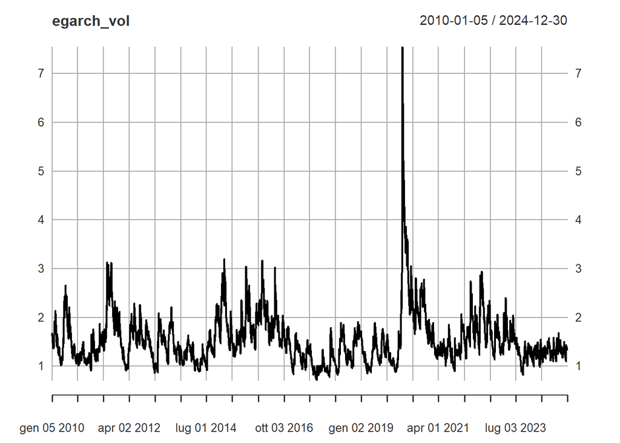

```r
egarch_vol <- sigma(egarch_fit)
plot(egarch_vol, type="l")
```

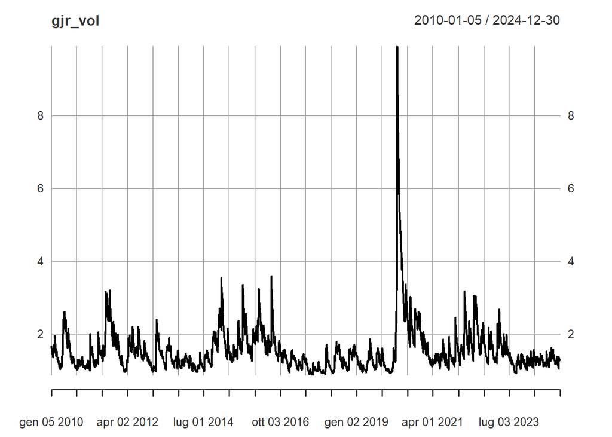

```r
min_len <- min(length(egarch_vol), length(realized_vol), length(returns))
df <- data.frame(
  Time = 1:min_len,
  PredictedVol = egarch_vol[1:min_len],
  RealizedVol = realized_vol[1:min_len]
)

p3 <- ggplot(df, aes(x = Time)) +
  geom_line(aes(y = PredictedVol, color = "Predicted Volatility (EGARCH)"), size = 1) +
  geom_line(aes(y = RealizedVol, color = "Realized Volatility (21-day Rolling SD)"), size = 0.5) +
  labs(
    title = "Predicted vs Realized Volatility",
    x = "Time",
    y = "Volatility",
    color = "Legend"
  ) +
  theme_minimal()
gjr_vol<-sigma(gjr_fit)
plot(gjr_vol)
```

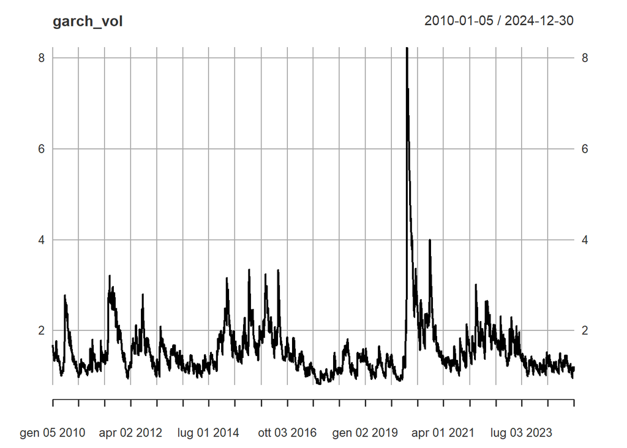

```r
min_len <- min(length(gjr_vol), length(realized_vol), length(returns))
df <- data.frame(
  Time = 1:min_len,
  PredictedVol = gjr_vol[1:min_len],
  RealizedVol = realized_vol[1:min_len]
)

p4 <- ggplot(df, aes(x = Time)) +
  geom_line(aes(y = PredictedVol, color = "Predicted Volatility (GJR-GARCH)"), size = 1) +
  geom_line(aes(y = RealizedVol, color = "Realized Volatility (21-day Rolling SD)"), size = 0.5) +
  labs(
    title = "Predicted vs Realized Volatility",
    x = "Time",
    y = "Volatility",
    color = "Legend"
  ) +
  theme_minimal()

garch_vol<-sigma(garch_fit)
plot(garch_vol)
```

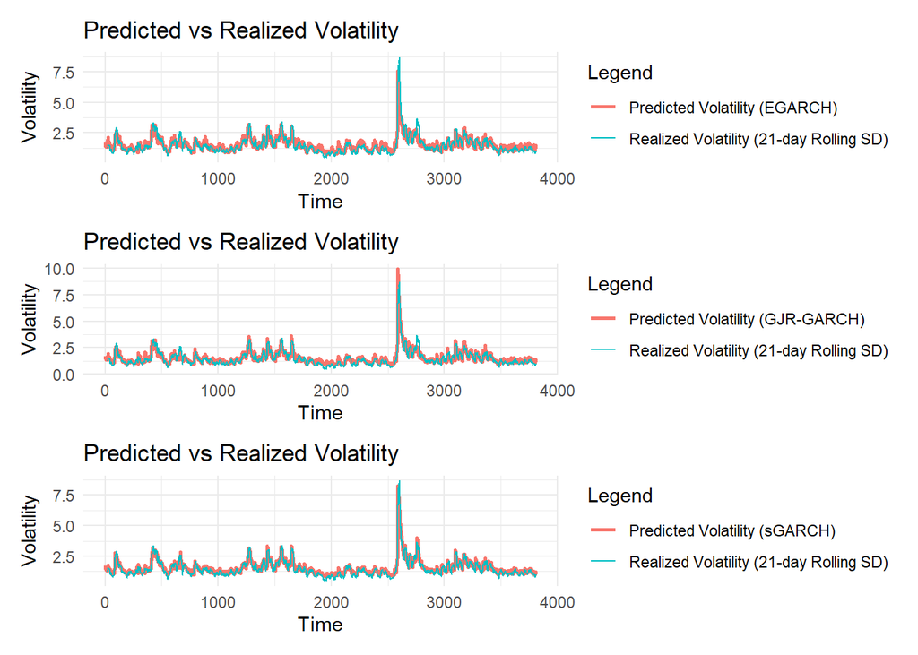

```r
min_len <- min(length(garch_vol), length(realized_vol), length(returns))
df <- data.frame(
  Time = 1:min_len,
  PredictedVol = garch_vol[1:min_len],
  RealizedVol = realized_vol[1:min_len]
)

p5 <- ggplot(df, aes(x = Time)) +
  geom_line(aes(y = PredictedVol, color = "Predicted Volatility (sGARCH)"), size = 1) +
  geom_line(aes(y = RealizedVol, color = "Realized Volatility (21-day Rolling SD)"), size = 0.5) +
  labs(
    title = "Predicted vs Realized Volatility",
    x = "Time",
    y = "Volatility",
    color = "Legend"
  ) +
  theme_minimal()

p3/p4/p5
```

## **Backtesting the model and analyzing the violations**

In this section, we evaluate the predictive accuracy of the models by comparing the forecasted volatility against the actual asset returns. The goal is to determine how well the model captures extreme variations in the market by calculating the number of violations outside a 90% confidence interval we build by estimating the 5% and 95% quantiles.

We verifiy whenever the realized returns fall below or exceed the lower and upper bound of this predictive interval. In these cases, we register what is called a *violation,* which are crucial to indicate where the model fails to anticipate extreme movements in the financial series.

1. **Garch models**

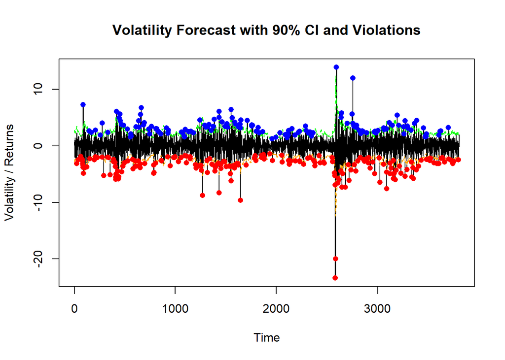

```r
y <- as.numeric(returns)
y <- as.numeric(y)
egarch_vol <- as.numeric(egarch_vol)
egarch_sum_lower<-sum(y<qnorm(0.05,0,egarch_vol))/length(y)
egarch_sum_upper<-sum(y>qnorm(0.95,0,egarch_vol))/length(y)
lower <- qnorm(0.05, 0, egarch_vol)
upper <- qnorm(0.95, 0, egarch_vol)
viol_lower <- which(y < lower)
viol_upper <- which(y > upper)
plot(y, type = "l", col = "black", lwd = 1,
     ylim = range(c(lower, upper, y)),
     ylab = "Volatility / Returns", xlab = "Time",
     main = "Volatility Forecast with 90% CI and Violations")
lines(lower, col = "orange", lty = 2)
lines(upper, col = "green", lty = 2)
points(viol_lower, y[viol_lower], col = "red", pch = 16)
points(viol_upper, y[viol_upper], col = "blue", pch = 16)
```

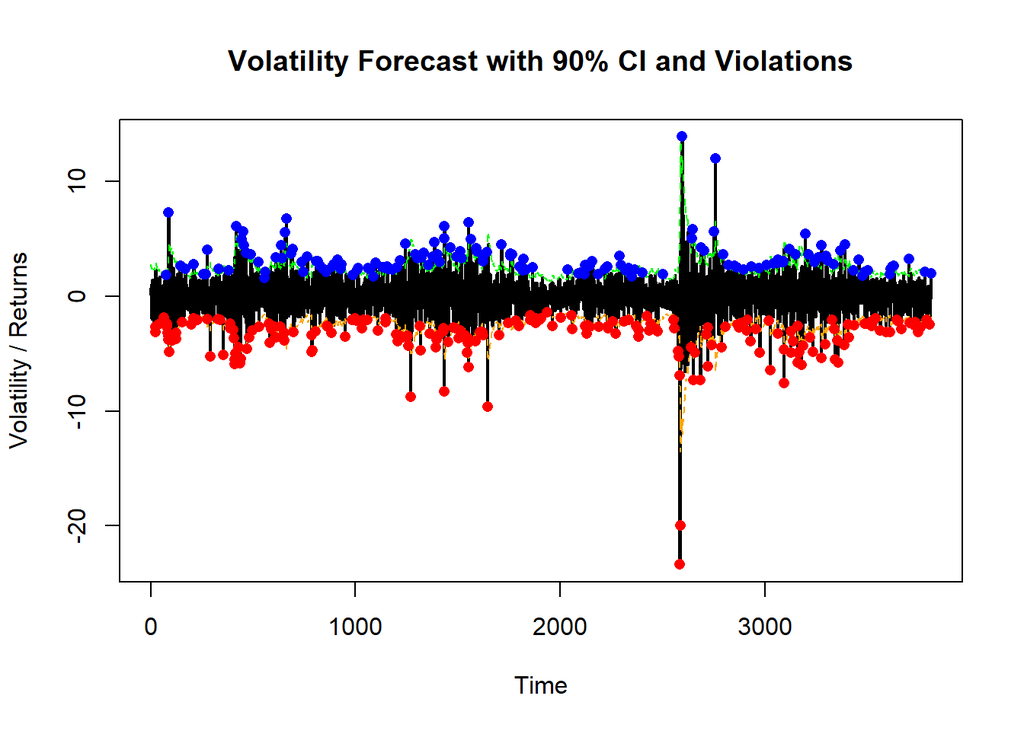

```r
y <- as.numeric(returns)
y <- as.numeric(y)
garch_vol <- as.numeric(garch_vol)
garch_sum_lower<-sum(y<qnorm(0.05,0,garch_vol))/length(y)
garch_sum_upper<-sum(y>qnorm(0.95,0,garch_vol))/length(y)
lower <- qnorm(0.05, 0, garch_vol)
upper <- qnorm(0.95, 0, garch_vol)
viol_lower <- which(y < lower)
viol_upper <- which(y > upper)
plot(y, type = "l", col = "black", lwd = 2,
     ylim = range(c(lower, upper, y)),  # include tutto nel grafico
     ylab = "Volatility / Returns", xlab = "Time",
     main = "Volatility Forecast with 90% CI and Violations")
lines(lower, col = "orange", lty = 2)
lines(upper, col = "green", lty = 2)
points(viol_lower, y[viol_lower], col = "red", pch = 16)
points(viol_upper, y[viol_upper], col = "blue", pch = 16)
```

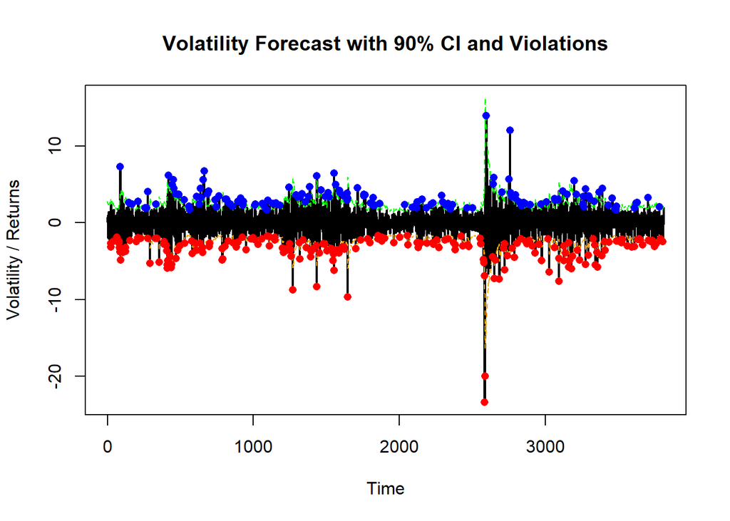

```r
y <- as.numeric(returns)
y <- as.numeric(y)
gjr_vol <- as.numeric(gjr_vol)
gjr_sum_lower<-sum(y<qnorm(0.05,0,gjr_vol))/length(y)
gjr_sum_upper<-sum(y>qnorm(0.95,0,gjr_vol))/length(y)
lower <- qnorm(0.05, 0, gjr_vol)
upper <- qnorm(0.95, 0, gjr_vol)
viol_lower <- which(y < lower)
viol_upper <- which(y > upper)
plot(y, type = "l", col = "black", lwd = 2,
     ylim = range(c(lower, upper, y)),  # include tutto nel grafico
     ylab = "Volatility / Returns", xlab = "Time",
     main = "Volatility Forecast with 90% CI and Violations")
lines(lower, col = "orange", lty = 2)
lines(upper, col = "green", lty = 2)
points(viol_lower, y[viol_lower], col = "red", pch = 16)
points(viol_upper, y[viol_upper], col = "blue", pch = 16)
```

```r
df_upper_viol <- data.frame(
  EGARCH = egarch_sum_upper,
  GARCH = garch_sum_upper,
  GJR = gjr_sum_upper
)

df_lower_viol <- data.frame(
  EGARCH = egarch_sum_lower,
  GARCH = garch_sum_lower,
  GJR = gjr_sum_lower
)
print(df_lower_viol)
```

```
##       EGARCH      GARCH        GJR
## 1 0.05143007 0.05352926 0.05379166
```

```r
print(df_upper_viol)
```

```
##       EGARCH      GARCH        GJR
## 1 0.03726056 0.03909735 0.03778536
```

The tables reports the percentage proportion of returns that exceeded the upper bound and the lower bound of the 90% confidence interval, as predicted by GARCH models.

For the upper bound:

- The **simple GARCH** model shows the highest upper violation rate at 3.91%, suggesting it underestimates upper-tail risk slightly less conservatively than the others.
- The **GJR-GARCH** and **EGARCH** models have slightly lower violation rates, at 3.78% and 3.73%, respectively, indicating a more conservative behavior in predicting extreme positive returns.

All models fall below the theoretical 5% threshold, implying that their predictive intervals are slightly too wide and may be overly cautious in capturing upper-tail events.

For the lower bound:

- The **EGARCH** model shows a lower-tail violation rate of **5.14%**, slightly exceeding the nominal level, suggesting a modest underestimation of downside risk.
- Both the **GARCH** (**5.35%**) and **GJR-GARCH** (**5.38%**) models exhibit even higher violation rates, implying a greater frequency of observed negative returns falling below their predicted lower bounds.

These results indicate that all three models slightly **undercover the lower tail**, with GARCH and GJR-GARCH models showing a stronger tendency to underestimate extreme negative movements in returns. This could point to limited responsiveness to volatility clustering or asymmetric shocks in downward trends.

2. **SV models**

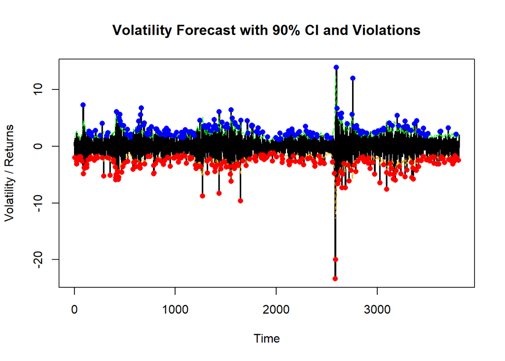

```r
y <- as.numeric(returns)
y <- as.numeric(y)
sv_lev <- as.numeric(sy_lev*exp(h_lev/2))
lev_lower_viol<-sum(y<qnorm(0.05,0,sy_lev*exp(h_lev/2)))/length(y)
lev_upper_viol<-sum(y>qnorm(0.95,0,sy_lev*exp(h_lev/2)))/length(y)
lower <- qnorm(0.05, 0, sy_lev*exp(h_lev/2))
upper <- qnorm(0.95, 0, sy_lev*exp(h_lev/2))
viol_lower <- which(y < lower)
viol_upper <- which(y > upper)
plot(y, type = "l", col = "black", lwd = 2,
     ylim = range(c(lower, upper, y)),  # include tutto nel grafico
     ylab = "Volatility / Returns", xlab = "Time",
     main = "Volatility Forecast with 90% CI and Violations")
lines(lower, col = "orange", lty = 2)
lines(upper, col = "green", lty = 2)
points(viol_lower, y[viol_lower], col = "red", pch = 16)
points(viol_upper, y[viol_upper], col = "blue", pch = 16)
```

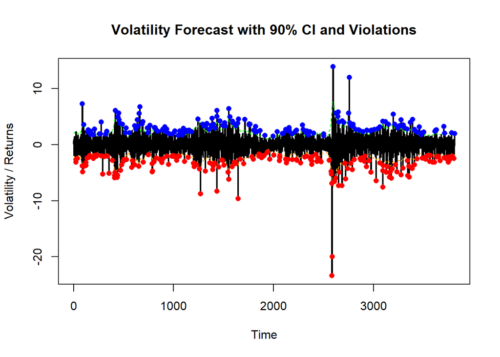

```r
y <- as.numeric(returns)
y <- as.numeric(y)
sv_lev <- as.numeric(sy_t*exp(h_t/2))
t_lower_viol<-sum(y<qnorm(0.05,0,sy_t*exp(h_t/2)))/length(y)
t_upper_viol<-sum(y>qnorm(0.95,0,sy_t*exp(h_t/2)))/length(y)
lower <- qnorm(0.05, 0, sy_t*exp(h_t/2))
upper <- qnorm(0.95, 0, sy_t*exp(h_t/2))
viol_lower <- which(y < lower)
viol_upper <- which(y > upper)
plot(y, type = "l", col = "black", lwd = 2,
     ylim = range(c(lower, upper, y)),  # include tutto nel grafico
     ylab = "Volatility / Returns", xlab = "Time",
     main = "Volatility Forecast with 90% CI and Violations")
lines(lower, col = "orange", lty = 2)
lines(upper, col = "green", lty = 2)
points(viol_lower, y[viol_lower], col = "red", pch = 16)
points(viol_upper, y[viol_upper], col = "blue", pch = 16)
```

```r
df_upper_viol <- data.frame(
  SV_leverage = lev_upper_viol,
  SV_tdist= t_upper_viol

)

df_lower_viol <- data.frame(
  SV_leverage = lev_lower_viol,
  Sv_tdist = t_lower_viol

)
print(df_lower_viol)
```

```
##   SV_leverage   Sv_tdist
## 1  0.05825243 0.04985568
```

```r
print(df_upper_viol)
```

```
##   SV_leverage   SV_tdist
## 1  0.04172133 0.04303332
```

For the lower bound:

- The **SV with leverage** model reports a lower-tail violation rate of **5.83%**, exceeding the nominal 5% threshold. This suggests a mild **undercoverage** of extreme negative returns, indicating that the model underestimates the downside risk slightly.
- In contrast, the **SV with Student’s t distribution** shows a lower violation rate of **4.99%**, almost exactly aligned with the expected value. This suggests that it provides **well-calibrated coverage** in the left tail of the return distribution.

For the upper bound:

- The **SV with leverage** model shows an upper violation rate of **4.17%**, slightly below the expected 5%, suggesting a marginal **overcoverage**. This implies that the model produces slightly conservative upper bounds, overestimating the extent of extreme positive returns.
- The **SV with Student’s t-distribution** has an upper violation rate of **4.30%**, also below the 5% threshold but slightly higher than the leverage model. This indicates a better-calibrated behavior, though still conservative in the upper tail.

Both models demonstrate good performance, staying close to the nominal coverage level. However, their slight overestimation in the upper tail reflects a tendency to issue wider-than-necessary prediction intervals for extreme positive returns, ensuring caution in volatile market scenarios.

On the basis the violation rates observed for both the lower and upper bounds of the 90% predictive intervals, the stochastic volatility model with Student’s t-distribution demonstrates the most reliable performance among the five models considered. Its violation percentages are 4.99% on the lower tail and 4.30% on the upper tail, both closely aligned with the theoretical nominal rate of 5%. This indicates that the model provides well-calibrated predictive intervals without systematically under- or overestimating tail risks.

## **Split the series into monthly blocks and fit the GEV distribution to the monthly maxima and minima**

### Introduction to Extreme Value Theory and the Block Maxima Approach

Extreme Value Theory is a statistical framework introduced to model the behavior of rare and extreme events that reside in the tails of a distribution. These extremes,like the largest daily or monthly gains or losses in financial markets, are often critical in risk management, stress testing, and the estimation of tail-dependent risk measures like Value-at-Risk (VaR).

One of the classical approach to implement the Extreme Value Theory is the **Block Maxima method**, which consists of dividing a time series into non-overlapping blocks, monthly in our cases, and extracting the maximum and minimum observation from each block. This process produces a new sequence of extremes, denoted:

$$M_n = \max \{ X_1, X_2, \ldots, X_n \},$$

where $X_i$ are i.i.d. observations from an unknown distribution $F$. According to the **Extremal Types Theorem** (Fisher-Tippett-Gnedenko), under suitable conditions there exist sequences $a_n > 0$ and $b_n \in \mathbb{R}$ such that:

$$\frac{M_n - b_n}{a_n} \xrightarrow{d} G(x), \quad \text{as } n \to
\infty,$$

where $G(x)$ is a non-degenerate limit distribution belonging to the **Generalized Extreme Value (GEV)** family. The cumulative distribution function of the GEV is given by:

$$G(x) = \exp \left\{ -\left[ 1 + \xi \left( \frac{x - \mu}{\sigma}
\right) \right]^{-1/\xi} \right\}, \quad \text{for } 1 + \xi \left(
\frac{x - \mu}{\sigma} \right) > 0,$$

and is characterized by three parameters:

- $\mu$: location parameter, indicating the central tendency of the extremes;
- $\sigma > 0$: scale parameter, measuring the dispersion;
- $\xi$: shape parameter, governing the tail behavior and defining to whatever of the GEV distribution the series belongs:
  - $\xi > 0$: Fréchet,
  - $\xi = 0$: Gumbel ,
  - $\xi < 0$: Weibull.

In this exercise, we apply the block maxima method to daily log-returns of the ENI stock from 2010 to 2024. The series is split into monthly blocks, from which we extract both the **maximum** and the **minimum** daily return for each month. Two GEV distributions are then fitted independently to these sequences.

Parameter estimation is performed via **maximum likelihood estimation (MLE)** (using the “ismev” package) , which ensures asymptotically efficient and consistent estimators under regularity conditions. The fitted GEV models provide a description of the behavior of ENI’s return distribution, enabling a clear distinction between the dynamics of extreme gains (upside potential) and extreme losses (downside risk). By modeling the maxima and minima separately, this approach captures the inherent **asymmetry** in financial return series, where negative shocks tend to be more abrupt and severe than the positive one.

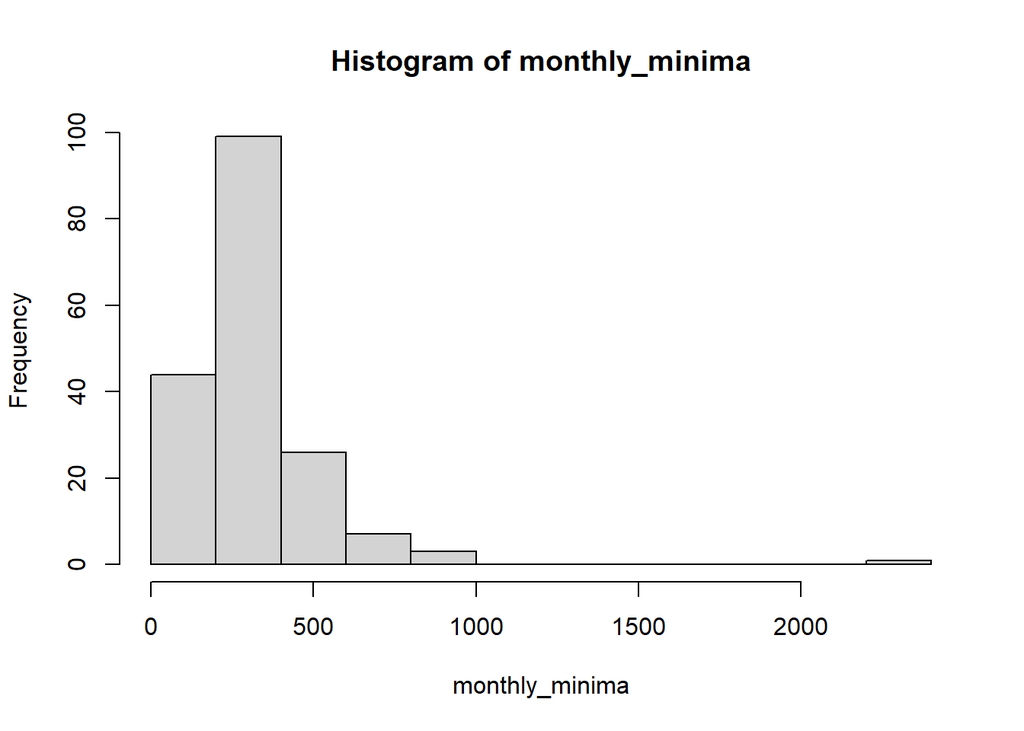

```r
year_month <- format(index(returns), "%Y-%m")
monthly_minima <- tapply(-100 * returns, FUN = max, INDEX = year_month)
monthly_maximum <- tapply(100 * returns, FUN = max, INDEX = year_month)
hist(monthly_minima)
```

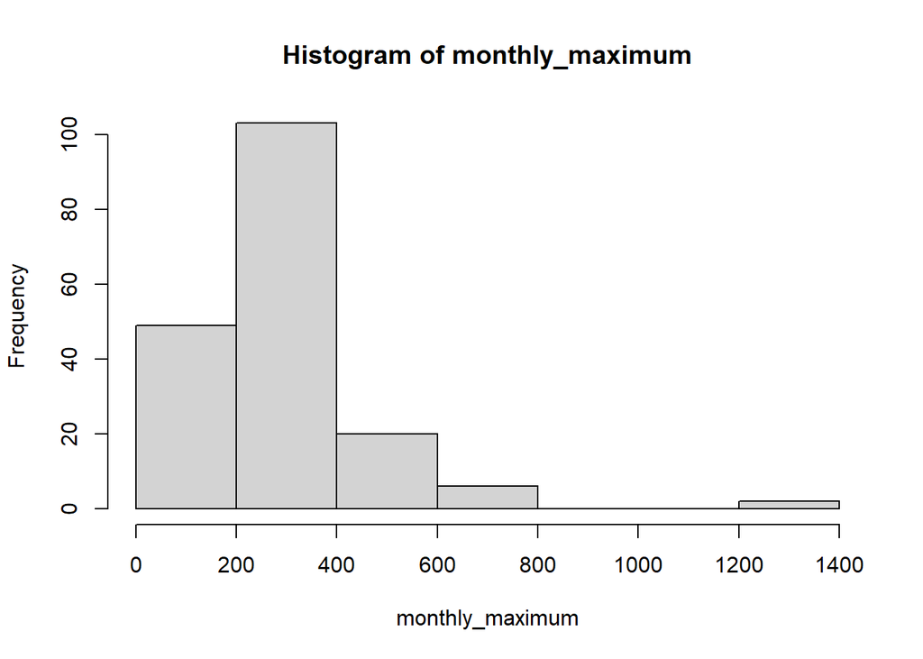

```r
hist(monthly_maximum)
```

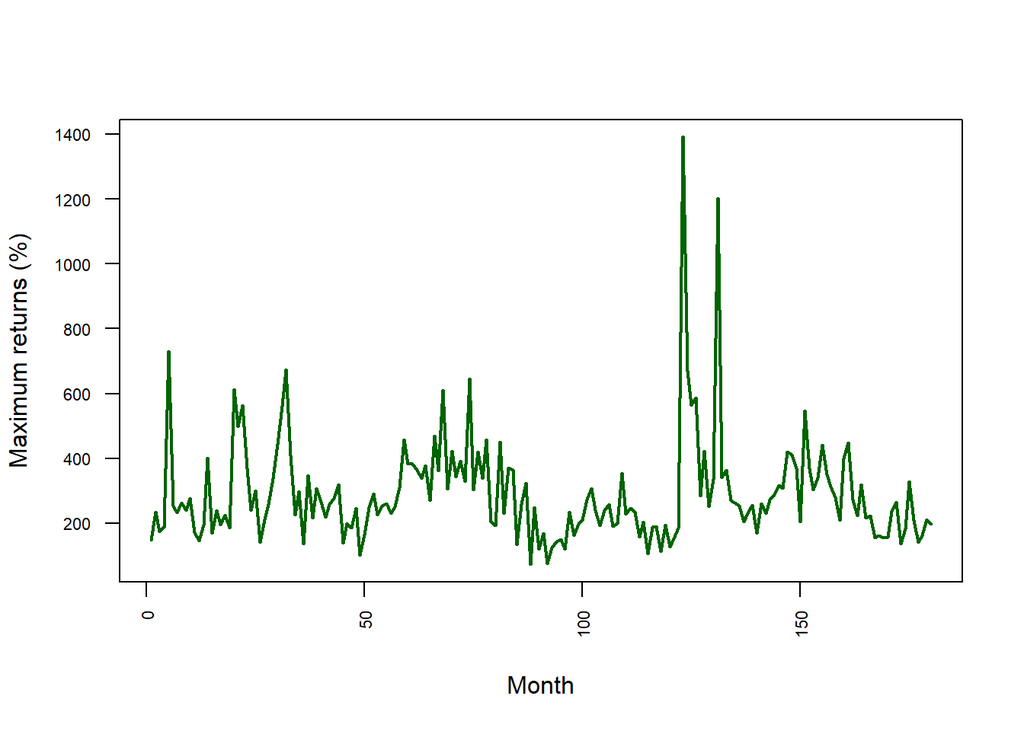

```r
plot(monthly_maximum,
     type = "l",
     col = "darkgreen",
     lwd = 2,
     xlab = "Month",
     ylab = "Maximum returns (%)",
     las = 2,
     cex.axis = 0.7)
```

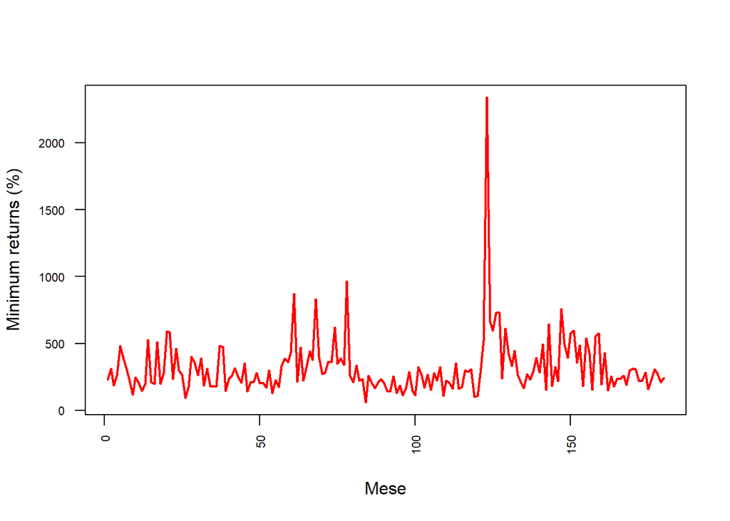

```r
plot(monthly_minima,
     type = "l",
     col = "red",
     lwd = 2,
     xlab = "Mese",
     ylab = "Minimum returns (%)",
     las = 2,
     cex.axis = 0.7)
```

After diving the series into block, and estracting the maximum and the minimum for each month ow we proceed to fit the GEV to our series:

```r
myfit_min <- gev.fit(as.numeric(monthly_minima))
```

```
## $conv
## [1] 0
##
## $nllh
## [1] 1140.585
##
## $mle
## [1] 227.957665 102.884123   0.218062
##
## $se
## [1] 8.56325664 6.84109970 0.05543552
```

```r
myfit_max <- gev.fit(as.numeric(monthly_maximum))
```

```
## $conv
## [1] 0
##
## $nllh
## [1] 1113.665
##
## $mle
## [1] 221.1847652  92.1359163   0.1550719
##
## $se
## [1] 7.64686195 5.87510954 0.05217124
```

By analyzing the results of the fit, we know that:

The positive value of the shape parameter $\xi$ = 0.218 indicates that the distribution of monthly minima belongs to the **Fréchet family, which is characterized by heavy tails**, implying that extreme negative returns although rare can be very large in magnitude.

The relatively large **scale parameter** further reflects the substantial dispersion observed in the left tail of the return distribution. Standard errors are low relative to parameter values, suggesting a reliable and stable estimation.

The shape parameter for maxima is also positive, indicating a **Fréchet** for the right tail too. However a $\xi$ value of 0.155 is smaller than that estimated for the minima, suggesting a **lighter tail** for extreme positive returns compared to extreme losses. This also implies less variability in the magnitude of extreme gains, due to a lower estimated **scale parameter**. Standard errors are again low, confirming the robustness of the estimates.

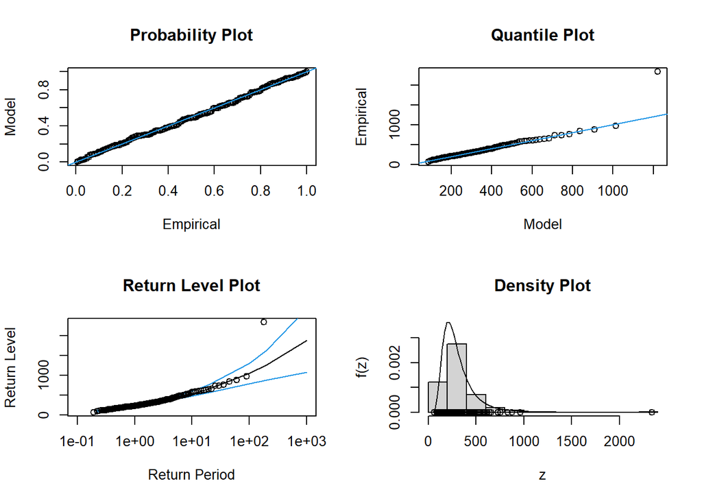

```r
gev.diag(myfit_min)
```

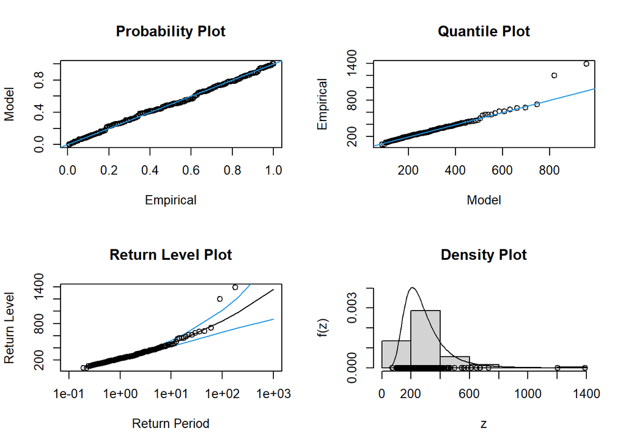

```r
gev.diag(myfit_max)
```

After fitting the GEV, we assessed the reliability of the results with a series of disgnostic plots produced by the gev.diag() function.

For the **monthly minima:**

Overall, the diagnostic evidence supports the suitability of the GEV model for characterizing the left tail of ENI’s return distribution over the 2010-2024 period. The model yields valuable insights into the frequency and severity of extreme losses and offers a principled way to extrapolate beyond the historical data.

For the monthly maximum:

1. **Probability plot**: it suggests a good agreement between the empirical and fitted distributions. The data points lie closely along the diagonal, indicating that the GEV model well captures the empirical cumulative distribution function (CDF). This supports the hypothesis that the monthly maxima conform to an extreme value law, at least in the central region of the distribution.
2. **Quantile plot**: most of the observed maxima align well with the theoretical quantiles. However, a few extreme observations in the upper tail exceed the fitted line, suggesting that the model may slightly underestimate the probability of the most extreme positive returns. Such behavior is typical when the shape parameter ξ is positive but small, implying a light to moderate upper tail.
3. **Return level plot**: it shows that values over 800 are expected approximately once every 100 periods. The GEV fit again captures the bulk of the observations, though some of the most extreme maxima lie just above the upper confidence bounds. This suggests a slight underestimation of extreme gains by the model—a point already noted in the quantile and density diagnostics. Nevertheless, the return level plot still offers a reasonable extrapolation framework for assessing upside risk.
4. **Density plot**: the histogram of the observed maxima shows a concentration of values around the mode of the distribution, with a thin right tail. The overlaid GEV density approximates the main body of the distribution well, although it appears to underestimate the right tail, in line with the earlier observations from the Q-Q and return level plots.

Even for the maximum distribution, the fitted GEV model offers a good first-order approximation for ENI’s returns.